# Practice Code: Day 2

Author

Constantin Manuel Bosancianu

Published

November 2, 2015

# 1 Introduction

**Warning**: the code chunk below will install packages on your system (if these are not already installed).

```r
library(pacman)
p_load(tidyverse, survival, knitr, ggthemes, simPH, lmtest)
```

```r
df_hmohiv <- readRDS(file = "../02-data/02-hmohiv.rds")
```

Conduct a quick examination of the data.

```r
df_hmohiv |>
  glimpse()
```

```
Rows: 100
Columns: 7
$ ID      <int> 1, 2, 3, 4, 5, 6, 7, 8, 9, 10, 11, 12, 13, 14, 15, 16, 17, 18,…
$ time    <int> 5, 6, 8, 3, 22, 1, 7, 9, 3, 12, 2, 12, 1, 15, 34, 1, 4, 19, 3,…
$ age     <int> 46, 35, 30, 30, 36, 32, 36, 31, 48, 47, 28, 34, 44, 32, 36, 36…
$ drug    <int> 0, 1, 1, 1, 0, 1, 1, 1, 0, 0, 1, 0, 1, 1, 0, 0, 0, 0, 1, 0, 0,…
$ censor  <int> 1, 0, 1, 1, 1, 0, 1, 1, 1, 1, 0, 1, 1, 1, 1, 1, 1, 0, 0, 1, 0,…
$ entdate <chr> "5/15/1990 ", "9/19/1989 ", "4/21/1991 ", "1/3/1991 ", "9/18/1…
$ enddate <chr> "10/14/1990 ", "3/20/1990 ", "12/20/1991 ", "4/4/1991 ", "7/19…
```

Finally, we include a pair of helpful functions to create plots for our survival analyses using `ggplot2`.[^1]

<sup>1</sup> The functions were created by Ramon Saccilotto, at the Basel Institute for Clinical Epidemiology and Biostatistics.

```r
createSurvivalFrame <- function(f.survfit){
# initialise frame variable
f.frame <- NULL
# check if more then one strata
if(length(names(f.survfit$strata)) == 0){
# create data.frame with data from survfit
f.frame <- data.frame(time=f.survfit$time, n.risk=f.survfit$n.risk, n.event=f.survfit$n.event, n.censor = f.survfit
$n.censor, surv=f.survfit$surv, upper=f.survfit$upper, lower=f.survfit$lower)
# create first two rows (start at 1)
f.start <- data.frame(time=c(0, f.frame$time[1]), n.risk=c(f.survfit$n, f.survfit$n), n.event=c(0,0),
n.censor=c(0,0), surv=c(1,1), upper=c(1,1), lower=c(1,1))
# add first row to dataset
f.frame <- rbind(f.start, f.frame)
# remove temporary data
rm(f.start)
}
else {
# create vector for strata identification
f.strata <- NULL
for(f.i in 1:length(f.survfit$strata)){
# add vector for one strata according to number of rows of strata
f.strata <- c(f.strata, rep(names(f.survfit$strata)[f.i], f.survfit$strata[f.i]))
}
# create data.frame with data from survfit (create column for strata)
f.frame <- data.frame(time=f.survfit$time, n.risk=f.survfit$n.risk, n.event=f.survfit$n.event, n.censor = f.survfit
$n.censor, surv=f.survfit$surv, upper=f.survfit$upper, lower=f.survfit$lower, strata=factor(f.strata))
# remove temporary data
rm(f.strata)
# create first two rows (start at 1) for each strata
for(f.i in 1:length(f.survfit$strata)){
# take only subset for this strata from data
f.subset <- subset(f.frame, strata==names(f.survfit$strata)[f.i])
# create first two rows (time: 0, time of first event)
f.start <- data.frame(time=c(0, f.subset$time[1]), n.risk=rep(f.survfit[f.i]$n, 2), n.event=c(0,0),
n.censor=c(0,0), surv=c(1,1), upper=c(1,1), lower=c(1,1), strata=rep(names(f.survfit$strata)[f.i],
2))
# add first two rows to dataset
f.frame <- rbind(f.start, f.frame)
# remove temporary data
rm(f.start, f.subset)
}
# reorder data
f.frame <- f.frame[order(f.frame$strata, f.frame$time), ]
# rename row.names
rownames(f.frame) <- NULL
}
# return frame
return(f.frame)
}


# define custom function to draw kaplan-meier curve with ggplot
qplot_survival <- function(f.frame, f.CI="default", f.shape=3){
# use different plotting commands dependig whether or not strata's are given
if("strata" %in% names(f.frame) == FALSE){
# confidence intervals are drawn if not specified otherwise
if(f.CI=="default" | f.CI==TRUE ){
# create plot with 4 layers (first 3 layers only events, last layer only censored)
# hint: censoring data for multiple censoring events at timepoint are overplotted
# (unlike in plot.survfit in survival package)
ggplot(data=f.frame) + geom_step(aes(x=time, y=surv), direction="hv") + geom_step(aes(x=time,
y=upper), directions="hv", linetype=2) + geom_step(aes(x=time,y=lower), direction="hv", linetype=2) +
geom_point(data=subset(f.frame, n.censor==1), aes(x=time, y=surv), shape=f.shape)
}
else {
# create plot without confidence intervals
ggplot(data=f.frame) + geom_step(aes(x=time, y=surv), direction="hv") +
geom_point(data=subset(f.frame, n.censor==1), aes(x=time, y=surv), shape=f.shape)
}
}
else {
if(f.CI=="default" | f.CI==FALSE){
# without CI
ggplot(data=f.frame, aes(group=strata, colour=strata)) + geom_step(aes(x=time, y=surv),
direction="hv") + geom_point(data=subset(f.frame, n.censor==1), aes(x=time, y=surv), shape=f.shape)
}
else {
# with CI (hint: use alpha for CI)
ggplot(data=f.frame, aes(colour=strata, group=strata)) + geom_step(aes(x=time, y=surv),
direction="hv") + geom_step(aes(x=time, y=upper), directions="hv", linetype=2, alpha=0.5) +
geom_step(aes(x=time,y=lower), direction="hv", linetype=2, alpha=0.5) +
geom_point(data=subset(f.frame, n.censor==1), aes(x=time, y=surv), shape=f.shape)
}
}
}
```

Before getting started, change the name of the outcome, so as to clarify what it encodes.

```r
df_hmohiv <- df_hmohiv |>
  rename(death = 5)
```

# 2 Cox proportional hazards model

`coxph()` is the function which implements the Cox PH model It uses a standard `Surv` object as the dependent variable. The rest of the formula looks like standard OLS (`~IV1 + IV2 + ...`).

```r
model.1 <- coxph(Surv(time, death) ~ drug + age,
                 data = df_hmohiv)
summary(model.1)
```

```
Call:
coxph(formula = Surv(time, death) ~ drug + age, data = df_hmohiv)

  n= 100, number of events= 80

        coef exp(coef) se(coef)     z Pr(>|z|)
drug 1.01670   2.76405  0.25622 3.968 7.24e-05 ***
age  0.09714   1.10202  0.01864 5.211 1.87e-07 ***
---
Signif. codes:  0 '***' 0.001 '**' 0.01 '*' 0.05 '.' 0.1 ' ' 1

     exp(coef) exp(-coef) lower .95 upper .95
drug     2.764     0.3618     1.673     4.567
age      1.102     0.9074     1.062     1.143

Concordance= 0.711  (se = 0.033 )
Likelihood ratio test= 39.13  on 2 df,   p=3e-09
Wald test            = 36.13  on 2 df,   p=1e-08
Score (logrank) test = 38.39  on 2 df,   p=5e-09
```

Based on the model output, we can obtain a variety of quantities of interest.

```r
predict(model.1, type = "risk", se.fit = TRUE) # hazard ratio
```

```
$fit
         1          2          3          4          5          6          7
 2.6237599  2.4911829  1.5327348  1.5327348  0.9932232  1.8614118  2.7453223
         8          9         10         11         12         13         14
 1.6890975  3.1863944  2.8914242  1.2620936  0.8178458  5.9716608  1.8614118
        15         16         17         18         19         20         21
 0.9932232  0.9932232  5.7072366  0.9012788  5.9716608  1.2062083  1.4648655
        22         23         24         25         26         27         28
 2.2605697  0.3411787  0.6734354  4.9172205  2.8914242  0.5545242  7.9920519
        29         30         31         32         33         34         35
 1.6143046  4.0489670  1.9604732  1.6143046  0.5545242  1.0945474  4.9172205
        36         37         38         39         40         41         42
 1.6890975  3.6741469  0.6734354  4.2644468  0.9932232  1.9604732  1.3292603
        43         44         45         46         47         48         49
 0.7421363  6.5808630  0.7421363  0.4566096  0.6110943  0.5802161  2.1604720
        50         51         52         53         54         55         56
 3.6741469  0.7421363  0.6110943  0.7421363 10.6960018  2.7453223  1.5327348
        57         58         59         60         61         62         63
 4.9172205  1.8614118  0.8178458  3.3340245  0.7421363  3.6741469  3.6741469
        64         65         66         67         68         69         70
 2.0513047  2.2605697  0.8178458  7.2522134  0.2549287  5.9716608  1.0945474
        71         72         73         74         75         76         77
 0.3411787  1.2062083  0.6734354  0.8178458  0.5031909  2.7453223  0.2313295
        78         79         80         81         82         83         84
 1.0392406  1.8614118  1.7789887  4.0489670  3.0253879  2.8914242  1.8614118
        85         86         87         88         89         90         91
 4.4620246  7.2522134  1.0392406  0.5545242  1.8614118  1.6890975  0.9012788
        92         93         94         95         96         97         98
 0.9932232  4.4620246  2.7453223  2.4911829  2.2605697  0.4566096  0.5031909
        99        100
 2.4911829  2.2605697

$se.fit
          1           2           3           4           5           6
0.299813023 0.399351669 0.320344382 0.320344382 0.001300351 0.344327340
          7           8           9          10          11          12
0.424103013 0.331286568 0.396944155 0.346429820 0.303513824 0.034893558
         13          14          15          16          17          18
0.782420243 0.344327340 0.001300351 0.001300351 0.798421873 0.018934444
         19          20          21          22          23          24
```

[output cut: 12 more lines]

```
0.424103013 0.320344382 0.661893411 0.344327340 0.034893558 0.485150174
         61          62          63          64          65          66
0.049296879 0.522058053 0.522058053 0.359795326 0.378025322 0.034893558
         67          68          69          70          71          72
0.927863232 0.132416671 0.782420243 0.018135914 0.120525176 0.039510057
         73          74          75          76          77          78
0.062256054 0.034893558 0.093481358 0.424103013 0.135103923 0.291578138
         79          80          81          82          83          84
0.344327340 0.147428176 0.563619693 0.452599136 0.346429820 0.344327340
         85          86          87          88          89          90
0.610131341 0.927863232 0.291578138 0.084253539 0.344327340 0.331286568
         91          92          93          94          95          96
0.018934444 0.001300351 0.610131341 0.424103013 0.399351669 0.378025322
         97          98          99         100
0.101644825 0.093481358 0.399351669 0.378025322
```

```r
predict(model.1, type = "lp", se.fit = TRUE) # linear predictor
```

```
$fit
           1            2            3            4            5            6
 0.964608363  0.912757675  0.427053564  0.427053564 -0.006799858  0.621335208
           7            8            9           10           11           12
 1.009898497  0.524194386  1.158890007  1.061749185  0.232771920 -0.201081502
          13           14           15           16           17           18
 1.787025073  0.621335208 -0.006799858 -0.006799858  1.741734940 -0.103940680
          19           20           21           22           23           24
 1.787025073  0.187481787  0.381763431  0.815616853 -1.075348900 -0.395363146
          25           26           27           28           29           30
 1.592743429  1.061749185 -0.589644790  2.078447540  0.478904253  1.398461785
          31           32           33           34           35           36
 0.673185897  0.478904253 -0.589644790  0.090340965  1.592743429  0.524194386
          37           38           39           40           41           42
 1.301320963 -0.395363146  1.450312474 -0.006799858  0.673185897  0.284622609
          43           44           45           46           47           48
-0.298222324  1.884165896 -0.298222324 -0.783926434 -0.492503968 -0.544354656
          49           50           51           52           53           54
 0.770326719  1.301320963 -0.298222324 -0.492503968 -0.298222324  2.369870006
          55           56           57           58           59           60
 1.009898497  0.427053564  1.592743429  0.621335208 -0.201081502  1.204180141
          61           62           63           64           65           66
-0.298222324  1.301320963  1.301320963  0.718476031  0.815616853 -0.201081502
          67           68           69           70           71           72
 1.981306718 -1.366771367  1.787025073  0.090340965 -1.075348900  0.187481787
          73           74           75           76           77           78
-0.395363146 -0.201081502 -0.686785612  1.009898497 -1.463912189  0.038490276
          79           80           81           82           83           84
 0.621335208  0.576045075  1.398461785  1.107039319  1.061749185  0.621335208
          85           86           87           88           89           90
 1.495602607  1.981306718  0.038490276 -0.589644790  0.621335208  0.524194386
          91           92           93           94           95           96
-0.103940680 -0.006799858  1.495602607  1.009898497  0.912757675  0.815616853
          97           98           99          100
-0.783926434 -0.686785612  0.912757675  0.815616853

$se.fit
         1          2          3          4          5          6          7
0.18509234 0.25301874 0.25875194 0.25875194 0.00130478 0.25237730 0.25596152
         8          9         10         11         12         13         14
```

[output cut: 12 more lines]

```
0.27235825 0.05722392 0.09450334 0.05722392 0.39930928 0.25596152 0.25875194
        57         58         59         60         61         62         63
0.29848892 0.25237730 0.03858420 0.26570015 0.05722392 0.27235825 0.27235825
        64         65         66         67         68         69         70
0.25121203 0.25142702 0.03858420 0.34454716 0.26226075 0.32017876 0.01733493
        71         72         73         74         75         76         77
0.20634161 0.03597464 0.07586363 0.03858420 0.13178276 0.25596152 0.28090046
        78         79         80         81         82         83         84
0.28602033 0.25237730 0.11053349 0.28010060 0.26020952 0.20373205 0.25237730
        85         86         87         88         89         90         91
0.28884001 0.34454716 0.28602033 0.11314305 0.25237730 0.25490389 0.01994449
        92         93         94         95         96         97         98
0.00130478 0.28884001 0.25596152 0.25301874 0.25142702 0.15042248 0.13178276
        99        100
0.25301874 0.25142702
```

```r
predict(model.1, type = "expected", se.fit = TRUE) # expected number of events
```

```
$fit
         1          2          3          4          5          6          7
0.71490988 0.85751666 0.79134066 0.22306610 1.25931365 0.13706746 1.11673001
         8          9         10         11         12         13         14
1.03056237 0.46373097 2.59361979 0.13164713 0.73361113 0.22506817 2.13025435
        15         16         17         18         19         20         21
1.70868060 0.03743396 1.18409623 1.06434345 1.08893271 0.11081648 0.15279797
        22         23         24         25         26         27         28
0.76039364 1.46053932 0.53849523 0.51290806 0.78784180 0.12382170 0.30121545
        29         30         31         32         33         34         35
1.57681740 0.58926521 0.18011213 0.06084213 0.75882047 0.44523513 1.02018940
        36         37         38         39         40         41         42
0.87206972 1.00111443 0.47114500 0.39178224 0.60599133 3.98791227 0.19345350
        43         44         45         46         47         48         49
0.45279669 0.95774394 1.38641702 0.23574449 0.48864576 1.67873905 0.22535567
        50         51         52         53         54         55         56
0.53471587 0.84932264 0.02303176 0.51920911 0.40312563 1.11673001 0.22306610
        57         58         59         60         61         62         63
0.71562622 0.17101118 1.30156485 0.48521627 0.54236459 2.93793652 0.53471587
        64         65         66         67         68         69         70
0.83442060 0.61594950 1.20620894 1.97604933 1.09131490 0.22506817 0.19959079
        71         72         73         74         75         76         77
0.77798158 0.04546124 0.22652521 2.08465208 0.52395955 0.56957966 0.66930556
        78         79         80         81         82         83         84
0.03916833 0.07015545 0.91847994 1.10324367 0.11402498 0.10897597 0.17101118
        85         86         87         88         89         90         91
2.03090414 0.53402612 0.72706750 0.70308458 0.75717680 1.55120675 0.18699081
        92         93         94         95         96         97         98
3.34834614 0.16817092 2.52120582 1.01335232 0.08519946 0.12441487 2.15409150
        99        100
0.25985164 0.08519946

$se.fit
  [1] 0.21210624 0.16469806 0.18751329 0.07198641 0.24205734 0.04114971
  [7] 0.23469816 0.22916847 0.16435817 0.69457354 0.04111611 0.15457149
 [13] 0.12529395 0.49700006 0.33343028 0.02420618 0.44074465 0.20738944
 [19] 0.24955564 0.03670147 0.04363132 0.15296374 0.45383818 0.12664696
 [25] 0.12592699 0.24149373 0.03921076 0.18099391 0.32287154 0.15233727
 [31] 0.05835113 0.03722827 0.17198381 0.11166887 0.23083439 0.19871948
 [37] 0.22111210 0.11355382 0.14865397 0.13424925 0.96792779 0.06193614
 [43] 0.10855722 0.28586121 0.28188215 0.07328765 0.11977474 0.59494847
 [49] 0.06483502 0.13701147 0.17932668 0.01673872 0.12060606 0.26620797
 [55] 0.23469816 0.07198641 0.19263727 0.05245913 0.25752515 0.12424560
 [61] 0.12060606 0.65603838 0.13701147 0.18449663 0.14113887 0.23855267
 [67] 0.56628615 0.36795353 0.12529395 0.05267957 0.21658868 0.02848814
 [73] 0.06300341 0.44983380 0.12908279 0.12338256 0.21817484 0.02781622
 [79] 0.04114971 0.22013841 0.24863669 0.06070161 0.06973161 0.05245913
 [85] 0.42062171 0.15969511 0.19903813 0.16023955 0.17299705 0.33488850
 [91] 0.05373822 0.82224869 0.08940500 0.51535399 0.21465986 0.04757667
 [97] 0.04625222 0.62226690 0.06464331 0.04757667
```

## 2.1 Plotting

To plot these predictions, we can use the functions we used yesterday as well. `survfit()` can be used to create survival curves from the model.

Obtain survival curves for a drug user aged 20.

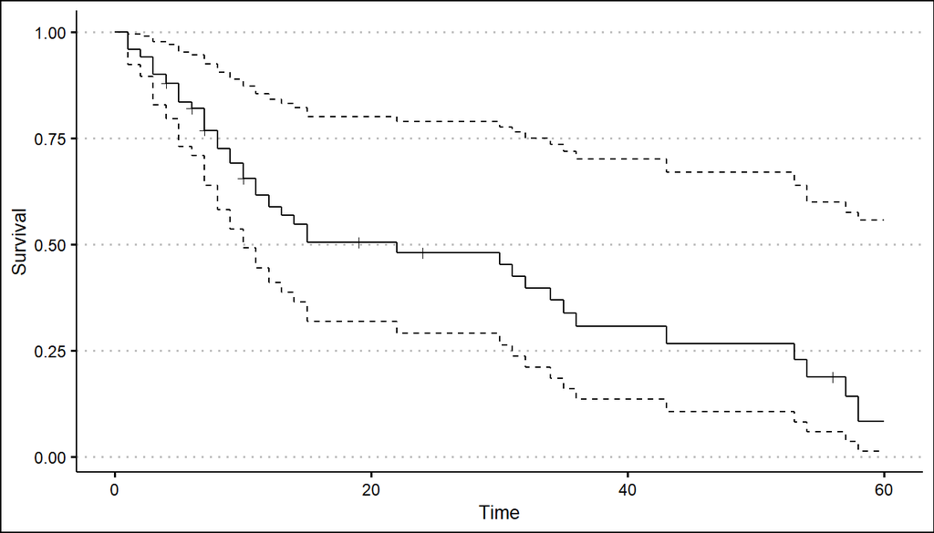

```r
df_test <- survfit(model.1,
                   newdata = data.frame(drug = 1, age = 20))
ObjSurv1 <- createSurvivalFrame(df_test)

qplot_survival(ObjSurv1) +
  labs(x = "Time",
       y = "Survival") +
    theme_clean()
```

```r
rm(df_test, ObjSurv1)
```

Compare with the survival curve for a drug user aged 40.

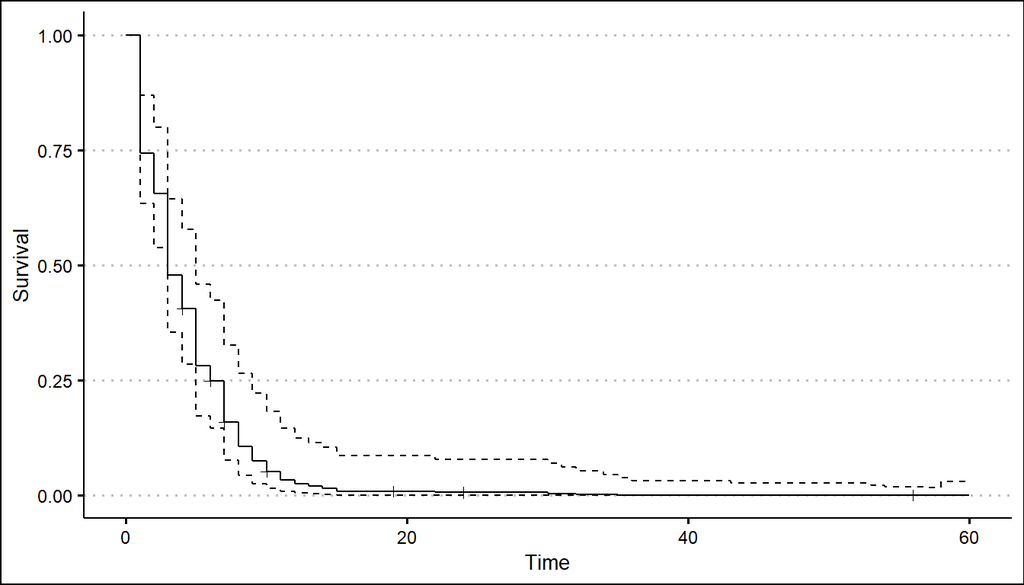

```r
df_test <- survfit(model.1,
                   newdata = data.frame(drug = 1, age = 40))
ObjSurv1 <- createSurvivalFrame(df_test)

qplot_survival(ObjSurv1) +
  labs(x = "Time",
       y = "Survival") +
    theme_clean()
```

```r
rm(df_test, ObjSurv1)
```

You can see from the comparison of the graphs that the younger person infected with HIV has better survival prospects.

## 2.2 Predictions

For predictions based on simulations you can use the `simPH` package. Before estimating the model, though, we need to center age.[^2]

<sup>2</sup> We need this because all hazards are compared to a reference age, which is 0. So we need to give age a meaningful 0 point.

```r
df_hmohiv <- df_hmohiv |>
  mutate(mean_age = age - mean(age, na.rm = TRUE))
```

```r
model.2 <- coxph(Surv(time, death) ~ drug + mean_age,
                 data = df_hmohiv)
```

The function which does the simulations is called `coxsimLinear()`. It needs from us the estimated model, which variable to plot, and the range of this variable for which predictions should be obtained. `simGG()`, from the same package, then plots the predictions.

```r
sim.2 <- coxsimLinear(model.2,
                      b = "mean_age",
                      Xj = seq(-10, 8, by = 0.25),
                      nsim = 250)
```

The smaller the `by =` interval, the smoother the graph.

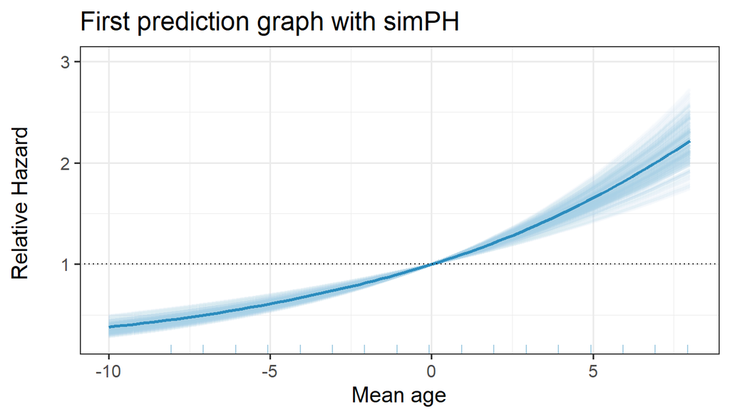

```r
graph1 <- simGG(sim.2,
                xlab = "Mean age",
                type = "lines",
                method = "loess")
graph1 +
  ggtitle("First prediction graph with simPH")
```

```r
rm(graph1)
```

We can also obtain predictions for a dichotomous variable in our specification. Here we would have to select `method = "lm"`, given that it’s a dichotomous predictor.

```r
sim.3 <- coxsimLinear(model.2,
                      b = "drug",
                      Xj = 0:1,
                      nsim = 250)
```

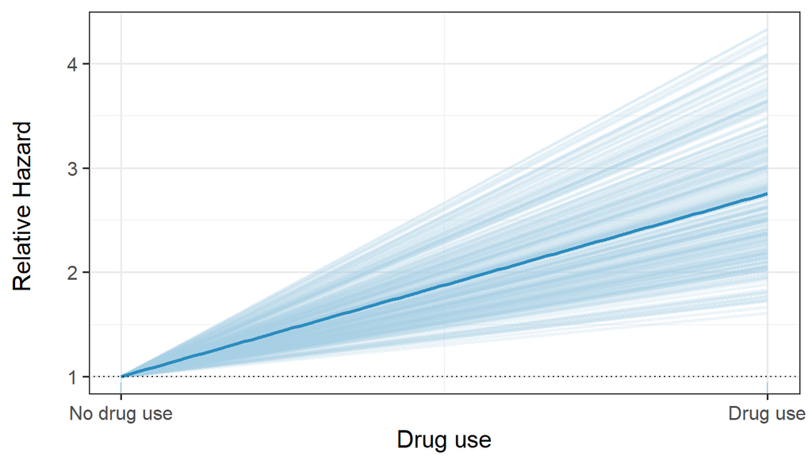

```r
graph2 <- simGG(sim.3,
                xlab = "Drug use",
                type = "lines",
                method = "lm")

graph2 +
  scale_x_continuous(limits = c(0, 1),
                     breaks = c(0, 1),
                     labels = c("No drug use", "Drug use"))
```

```r
rm(model.1, model.2, sim.1, sim.2, graph.2, sim.3)
```

# 3 Checking PH assumption

To check whether the proportional hazards (PH) assumption is valid, we need to get log-log survival curves.

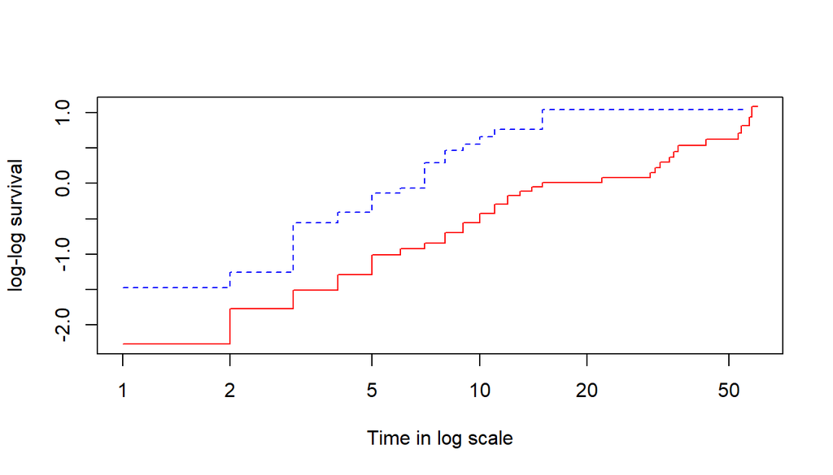

```r
model.1 <- survfit(Surv(time, death) ~ drug,
                   data = df_hmohiv)

plot(model.1,
     fun = "cloglog",
     lty = c("solid", "dashed"),
     col = c("red", "blue"),
     xlab = "Time in log scale",
     ylab = "log-log survival")
```

It seems we’re OK in terms of the PH assumption.

We can do this for continuous predictors as well, as long as we recode them into a fixed number of groups. For the sake of producing a manageable graph, these groups would usually be between 2 and 4.

```r
vec_quant_age <- quantile(df_hmohiv$age,
                          c(0.333, 0.666))

df_hmohiv <- df_hmohiv |>
  mutate(age_cat = case_when(age < vec_quant_age[1] ~ 0,
                             age >= vec_quant_age[1] &
                              age < vec_quant_age[2] ~ 1,
                             age >= vec_quant_age[2] ~ 2))
rm(vec_quant_age)
```

Run the `survfit()` function again, to get the survival curves.

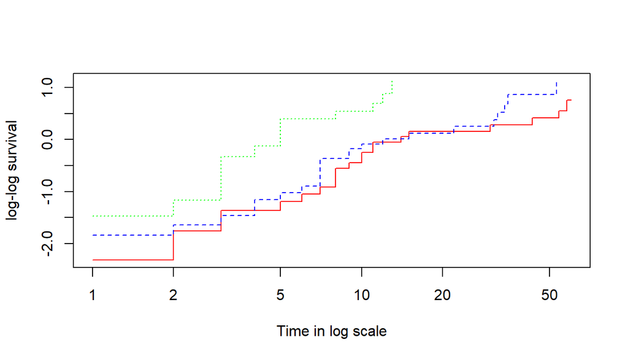

```r
model.1 <- survfit(Surv(time, death) ~ age_cat,
                   data = df_hmohiv)
plot(model.1,
     fun = "cloglog",
     lty = c("solid", "dashed", "dotted"),
     col = c("red", "blue", "green"),
     xlab = "Time in log scale",
     ylab = "log-log survival")
```

## 3.1 GOF approach

Fit a Cox model, and try to see the tests for each parameter. This is done with the `cox.zph()` function.[^3]

<sup>3</sup> The `global =` argument does a global $\chi^2$ test in addition to one for each variable.

```r
model.1 <- coxph(Surv(time, death) ~ drug + age,
                 data = df_hmohiv)

cox.zph(model.1,
        transform = "km",
        global = FALSE)
```

```
        chisq df    p
drug 0.000158  1 0.99
age  0.017640  1 0.89
```

## 3.2 Time-varying approach

This approach is based on running an interaction with time, to see whether the assumption is valid with respect to the drug use indicator.

This should be done through the `tt =` approach presented here. If we just interact drug with time, the model gives you convergence errors, because `time` also appears as a DV, technically.

```r
model.2 <- coxph(Surv(time, death) ~ drug + age + tt(drug),
                 data = df_hmohiv,
                 tt = function(x, t, ...) x * t)

summary(model.2)
```

```
Call:
coxph(formula = Surv(time, death) ~ drug + age + tt(drug), data = df_hmohiv,
    tt = function(x, t, ...) x * t)

  n= 100, number of events= 80

             coef exp(coef) se(coef)      z Pr(>|z|)
drug      1.19633   3.30796  0.34992  3.419 0.000629 ***
age       0.09487   1.09951  0.01892  5.013 5.35e-07 ***
tt(drug) -0.02828   0.97212  0.03878 -0.729 0.465940
---
Signif. codes:  0 '***' 0.001 '**' 0.01 '*' 0.05 '.' 0.1 ' ' 1

         exp(coef) exp(-coef) lower .95 upper .95
drug        3.3080     0.3023     1.666     6.568
age         1.0995     0.9095     1.059     1.141
tt(drug)    0.9721     1.0287     0.901     1.049

Concordance= 0.708  (se = 0.034 )
Likelihood ratio test= 39.81  on 3 df,   p=1e-08
Wald test            = 36.35  on 3 df,   p=6e-08
Score (logrank) test = 38.95  on 3 df,   p=2e-08
```

```r
rm(model.2, model.1, df_hmohiv)
```

# 4 Advanced specifications

We start with a new data set for this section.

```r
df_uis <- read.table("../02-data/03-uissurv.dat",
                     quote = "\"",
                     comment.char = "")
```

A bit of recoding is needed to correct for improperly reading the data. Dots need to be replaced with `NA`s, and variables need to be coerced to be considered numeric.

```r
df_uis <- df_uis |>
  rename(id = 1,
         age = 2,
         becktota = 3,
         hercoc = 4,
         ivhx = 5,
         ndrugtx = 6,
         race = 7,
         treat = 8,
         site = 9,
         lot = 10,
         time = 11,
         censor = 12) |>
  mutate(becktota = if_else(becktota == ".", NA_character_, becktota),
         hercoc = if_else(hercoc == ".", NA_character_, hercoc),
         ivhx = if_else(ivhx == ".", NA_character_, ivhx),
         race = if_else(race == ".", NA_character_, race),
         age = if_else(age == ".", NA_character_, age)) |>
  mutate_at(.vars = vars(becktota, hercoc, ivhx, race, age),
            .funs = as.numeric)
```

## 4.1 Stratified Cox model

```r
model.3 <- coxph(Surv(time, censor) ~ age + becktota + ivhx + treat +
                  site + lot,
                 data = df_uis,
                 na.action = na.omit)

summary(model.3)
```

```
Call:
coxph(formula = Surv(time, censor) ~ age + becktota + ivhx +
    treat + site + lot, data = df_uis, na.action = na.omit)

  n= 591, number of events= 475
   (37 observations deleted due to missingness)

               coef  exp(coef)   se(coef)       z Pr(>|z|)
age      -0.0196807  0.9805117  0.0079033  -2.490   0.0128 *
becktota  0.0040371  1.0040453  0.0047896   0.843   0.3993
ivhx      0.3014561  1.3518257  0.0570247   5.286 1.25e-07 ***
treat     0.1520115  1.1641736  0.0942117   1.614   0.1066
site      0.4972081  1.6441247  0.1071282   4.641 3.46e-06 ***
lot      -0.0092848  0.9907582  0.0008012 -11.588  < 2e-16 ***
---
Signif. codes:  0 '***' 0.001 '**' 0.01 '*' 0.05 '.' 0.1 ' ' 1

         exp(coef) exp(-coef) lower .95 upper .95
age         0.9805     1.0199    0.9654    0.9958
becktota    1.0040     0.9960    0.9947    1.0135
ivhx        1.3518     0.7397    1.2089    1.5117
treat       1.1642     0.8590    0.9679    1.4003
site        1.6441     0.6082    1.3327    2.0283
lot         0.9908     1.0093    0.9892    0.9923

Concordance= 0.735  (se = 0.011 )
Likelihood ratio test= 180.9  on 6 df,   p=<2e-16
Wald test            = 159.6  on 6 df,   p=<2e-16
Score (logrank) test = 162.4  on 6 df,   p=<2e-16
```

Something isn’t exactly right there.

```r
cox.zph(model.3,
        transform = "km",
        global = FALSE)
```

```
           chisq df      p
age        0.299  1 0.5847
becktota   2.575  1 0.1085
ivhx       0.038  1 0.8455
treat      9.882  1 0.0017
site       3.046  1 0.0809
lot      207.034  1 <2e-16
```

To overcome this we need to recode `lot` into a few categories.

```r
vec_quant_lot <- quantile(df_uis$lot,
                          c(0.333, 0.666))

df_uis <- df_uis |>
  mutate(lot_cat = case_when(lot < vec_quant_lot[1] ~ 0,
                             lot >= vec_quant_lot[1] &
                              lot < vec_quant_lot[2] ~ 1,
                             lot >= vec_quant_lot[2] ~ 2))
rm(vec_quant_lot)
```

Run the model again, this time stratifying on the recoded variable.

```r
model.4 <- coxph(Surv(time, censor) ~ age + becktota + ivhx + treat + site +
                  strata(lot_cat),
                data = df_uis,
                na.action = na.omit)
summary(model.4)
```

```
Call:
coxph(formula = Surv(time, censor) ~ age + becktota + ivhx +
    treat + site + strata(lot_cat), data = df_uis, na.action = na.omit)

  n= 591, number of events= 475
   (37 observations deleted due to missingness)

              coef exp(coef)  se(coef)      z Pr(>|z|)
age      -0.021210  0.979014  0.008071 -2.628   0.0086 **
becktota  0.005154  1.005167  0.004777  1.079   0.2806
ivhx      0.243888  1.276202  0.056781  4.295 1.75e-05 ***
treat     0.026370  1.026720  0.101041  0.261   0.7941
site      0.213500  1.238003  0.113606  1.879   0.0602 .
---
Signif. codes:  0 '***' 0.001 '**' 0.01 '*' 0.05 '.' 0.1 ' ' 1

         exp(coef) exp(-coef) lower .95 upper .95
age          0.979     1.0214    0.9636    0.9946
becktota     1.005     0.9949    0.9958    1.0146
ivhx         1.276     0.7836    1.1418    1.4264
treat        1.027     0.9740    0.8423    1.2516
site         1.238     0.8078    0.9909    1.5468

Concordance= 0.558  (se = 0.014 )
Likelihood ratio test= 24.28  on 5 df,   p=2e-04
Wald test            = 24.08  on 5 df,   p=2e-04
Score (logrank) test = 24.2  on 5 df,   p=2e-04
```

Plot the survival curves for the three groups.[^4]

<sup>4</sup> Run the following lines at once for all the elements to appear (legend and axes).

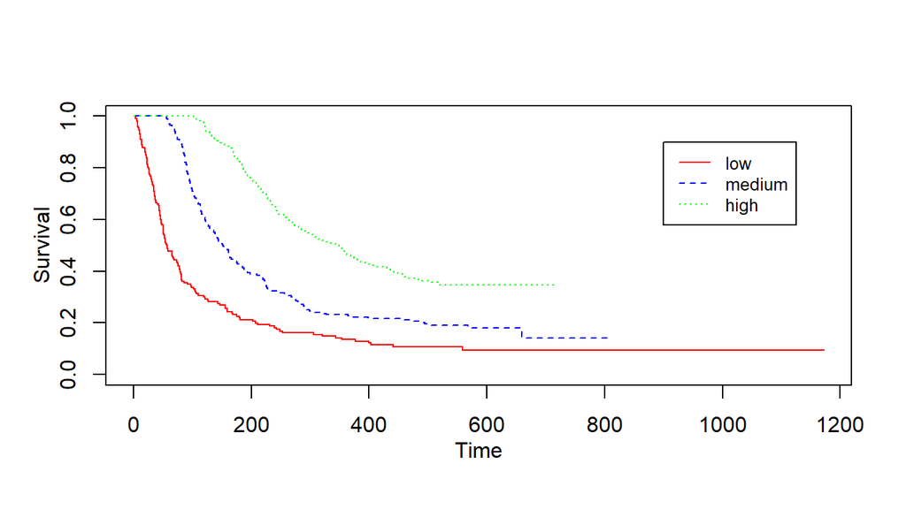

```r
plot(survfit(model.4),
     lty = c("solid", "dashed", "dotted"),
     col = c("red", "blue", "green"))
legend(900, .9,
       c("low", "medium", "high"),
       lty = 1:3,
       col = c("red", "blue", "green"),
       cex = 0.8, border = "black",
       text.col = "black", bg = "transparent")
mtext("Time", side = 1, col = "black", line = 2)
mtext("Survival", side = 2, col = "black", line = 2)
```

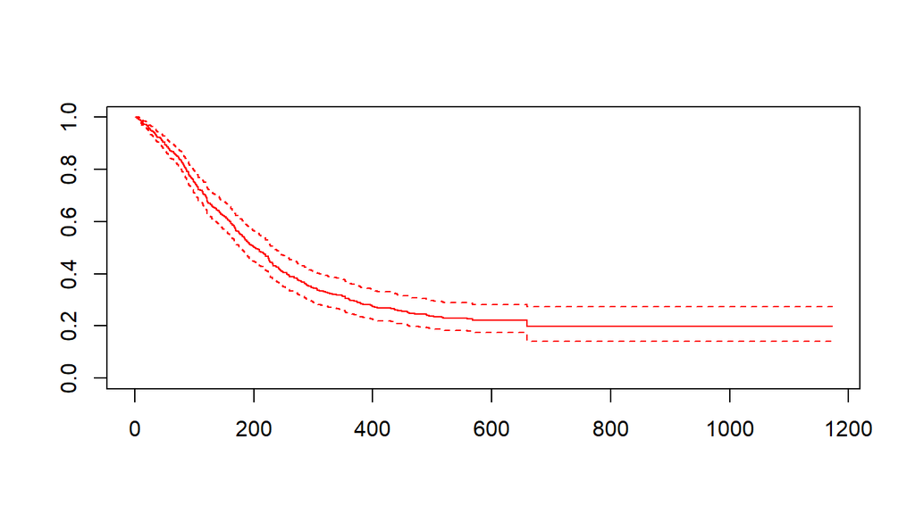

```r
plot(survfit(model.3),
     col = "red")
```

```r
rm(model.3, model.4)
```

This following section illustrates how we might check if the coefficients vary between strata. I’ve recoded `lot` into two groups now, to make things more manageable.

```r
vec_quant_lot <- quantile(df_uis$lot,
                          0.5)

df_uis <- df_uis |>
  mutate(lot_cat = if_else(lot < vec_quant_lot[1], 0, 1))
rm(vec_quant_lot)
```

Now we run a specification with stratification.

```r
model.4.1 <- coxph(Surv(time, censor) ~ age + becktota + ivhx + treat + site +
                    strata(lot_cat),
                   data = df_uis,
                   na.action = na.omit)
```

Now run the specification with interactions. Every IV can be interacted with the new stratification variable, or only some (depending on the theory).

```r
model.4.2 <- coxph(Surv(time, censor) ~ age + becktota + ivhx + treat + site +
                      lot_cat + age * lot_cat + becktota * lot_cat +
                      ivhx * lot_cat + treat * lot_cat + site * lot_cat,
                   data = df_uis,
                   na.action = na.omit)
```

Examine the results for model 1.

```r
round(summary(model.4.1)$coefficients,
      digits = 3)
```

```
           coef exp(coef) se(coef)      z Pr(>|z|)
age      -0.019     0.981    0.008 -2.394    0.017
becktota  0.007     1.007    0.005  1.437    0.151
ivhx      0.261     1.298    0.057  4.595    0.000
treat    -0.144     0.866    0.093 -1.543    0.123
site      0.079     1.082    0.106  0.741    0.459
```

Examine the results for model 2.

```r
round(summary(model.4.2)$coefficients,
      digits = 3)
```

```
                   coef exp(coef) se(coef)      z Pr(>|z|)
age              -0.042     0.959    0.012 -3.584    0.000
becktota          0.004     1.004    0.007  0.594    0.552
ivhx              0.433     1.543    0.084  5.154    0.000
treat             0.088     1.092    0.133  0.661    0.509
site              0.608     1.837    0.152  3.992    0.000
lot_cat          -1.299     0.273    0.548 -2.371    0.018
age:lot_cat       0.035     1.036    0.016  2.214    0.027
becktota:lot_cat  0.005     1.005    0.010  0.506    0.613
ivhx:lot_cat     -0.242     0.785    0.115 -2.105    0.035
treat:lot_cat    -0.359     0.698    0.187 -1.921    0.055
site:lot_cat     -0.788     0.455    0.210 -3.750    0.000
```

Check if the second model fits the data better.

```r
lrtest(model.4.1, model.4.2)
```

```
Likelihood ratio test

Model 1: Surv(time, censor) ~ age + becktota + ivhx + treat + site + strata(lot_cat)
Model 2: Surv(time, censor) ~ age + becktota + ivhx + treat + site + lot_cat +
    age * lot_cat + becktota * lot_cat + ivhx * lot_cat + treat *
    lot_cat + site * lot_cat
  #Df  LogLik Df  Chisq Pr(>Chisq)
1   5 -2387.5
2  11 -2664.1  6 553.18  < 2.2e-16 ***
---
Signif. codes:  0 '***' 0.001 '**' 0.01 '*' 0.05 '.' 0.1 ' ' 1
```

```r
rm(model.4.1, model.4.2)
```

It seems it does, which means the coefficients are not the same between strata. This model wouldn’t work very well here.

## 4.2 Extended Cox model

For this section we’ll use the `heart` data, which is available in the `survival` package.

```r
data(heart)

heart |>
  glimpse()
```

```
Rows: 172
Columns: 8
$ start      <dbl> 0, 0, 0, 1, 0, 36, 0, 0, 0, 51, 0, 0, 0, 12, 0, 26, 0, 0, 1…
$ stop       <dbl> 50, 6, 1, 16, 36, 39, 18, 3, 51, 675, 40, 85, 12, 58, 26, 1…
$ event      <dbl> 1, 1, 0, 1, 0, 1, 1, 1, 0, 1, 1, 1, 0, 1, 0, 1, 1, 0, 1, 0,…
$ age        <dbl> -17.15537303, 3.83572895, 6.29705681, 6.29705681, -7.737166…
$ year       <dbl> 0.1232033, 0.2546201, 0.2655715, 0.2655715, 0.4900753, 0.49…
$ surgery    <dbl> 0, 0, 0, 0, 0, 0, 0, 0, 0, 0, 0, 0, 0, 0, 0, 0, 0, 0, 0, 0,…
$ transplant <fct> 0, 0, 0, 1, 0, 1, 0, 0, 0, 1, 0, 0, 0, 1, 0, 1, 0, 0, 1, 0,…
$ id         <dbl> 1, 2, 3, 3, 4, 4, 5, 6, 7, 7, 8, 9, 10, 10, 11, 11, 12, 13,…
```

We first run a basic Cox PH model; we then specify start and stop times. There’s no need to cluster observations, since the software knows what observation to select for inclusion in the likelihood function.

```r
model.5 <- coxph(Surv(start, stop, event) ~ transplant + surgery +
                     age + year,
                 data = heart)
summary(model.5)
```

```
Call:
coxph(formula = Surv(start, stop, event) ~ transplant + surgery +
    age + year, data = heart)

  n= 172, number of events= 75

                coef exp(coef) se(coef)      z Pr(>|z|)
transplant1 -0.01025   0.98980  0.31375 -0.033   0.9739
surgery     -0.63721   0.52877  0.36723 -1.735   0.0827 .
age          0.02717   1.02754  0.01371  1.981   0.0476 *
year        -0.14635   0.86386  0.07047 -2.077   0.0378 *
---
Signif. codes:  0 '***' 0.001 '**' 0.01 '*' 0.05 '.' 0.1 ' ' 1

            exp(coef) exp(-coef) lower .95 upper .95
transplant1    0.9898     1.0103    0.5352    1.8307
surgery        0.5288     1.8912    0.2574    1.0860
age            1.0275     0.9732    1.0003    1.0555
year           0.8639     1.1576    0.7524    0.9918

Concordance= 0.636  (se = 0.033 )
Likelihood ratio test= 15.11  on 4 df,   p=0.004
Wald test            = 14.49  on 4 df,   p=0.006
Score (logrank) test = 15.03  on 4 df,   p=0.005
```

Plot survival curves for a 28 year-old respondent, with no transplant.[^5]

<sup>5</sup> In the data set, `age` is already centered around the value of 48 years, i.e. a person that is 38 years-old has a value of -10 on `age`.

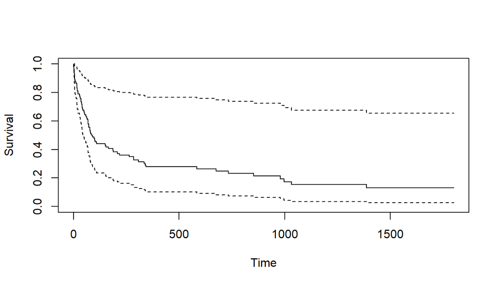

```r
plot(survfit(model.5,
             newdata = data.frame(transplant = 0,
                                  age = -20,
                                  surgery = 0,
                                  year = 0)),
     xlab = "Time",
     ylab = "Survival")
```

Plot survival curves for a 58 year-old respondent, with no transplant.

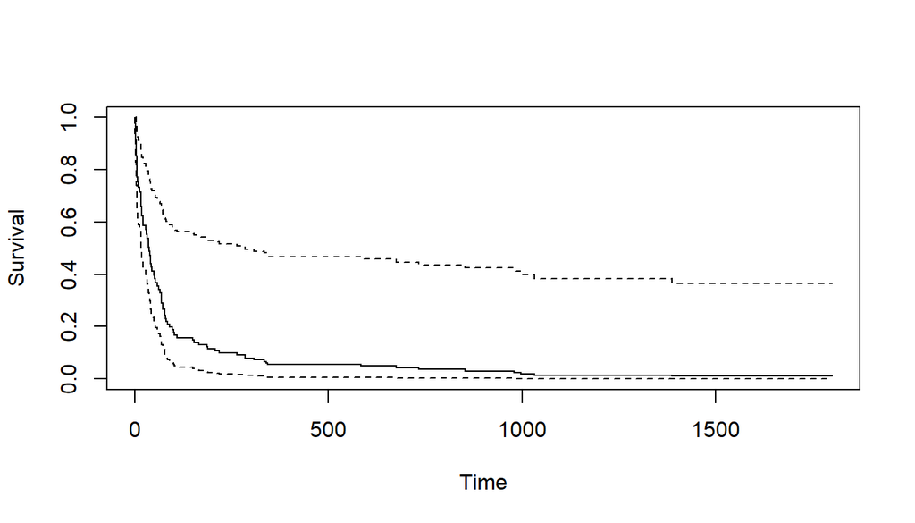

```r
plot(survfit(model.5,
             newdata = data.frame(transplant = 0,
                                  age = 10,
                                  surgery = 0,
                                  year = 0)),
     xlab = "Time",
     ylab = "Survival")
```